```python
import numpy as np
import pandas as pd
import matplotlib.pyplot as plt
import seaborn as sns
```

```python
salaryPredict = pd.read_csv("/Users/joshuarodriguez/Downloads/salary.csv")
salaryPredict.head()
```

|  | age | workclass | fnlwgt | education | education-num | marital-status | occupation | relationship | race | sex | capital-gain | capital-loss | hours-per-week | native-country | salary |
| --- | --- | --- | --- | --- | --- | --- | --- | --- | --- | --- | --- | --- | --- | --- | --- |
| 0 | 39 | State-gov | 77516 | Bachelors | 13 | Never-married | Adm-clerical | Not-in-family | White | Male | 2174 | 0 | 40 | United-States | <=50K |
| 1 | 50 | Self-emp-not-inc | 83311 | Bachelors | 13 | Married-civ-spouse | Exec-managerial | Husband | White | Male | 0 | 0 | 13 | United-States | <=50K |
| 2 | 38 | Private | 215646 | HS-grad | 9 | Divorced | Handlers-cleaners | Not-in-family | White | Male | 0 | 0 | 40 | United-States | <=50K |
| 3 | 53 | Private | 234721 | 11th | 7 | Married-civ-spouse | Handlers-cleaners | Husband | Black | Male | 0 | 0 | 40 | United-States | <=50K |
| 4 | 28 | Private | 338409 | Bachelors | 13 | Married-civ-spouse | Prof-specialty | Wife | Black | Female | 0 | 0 | 40 | Cuba | <=50K |

```python
salaryPredict.count()
```

```
age               32561
workclass         32561
fnlwgt            32561
education         32561
education-num     32561
marital-status    32561
occupation        32561
relationship      32561
race              32561
sex               32561
capital-gain      32561
capital-loss      32561
hours-per-week    32561
native-country    32561
salary            32561
dtype: int64
```

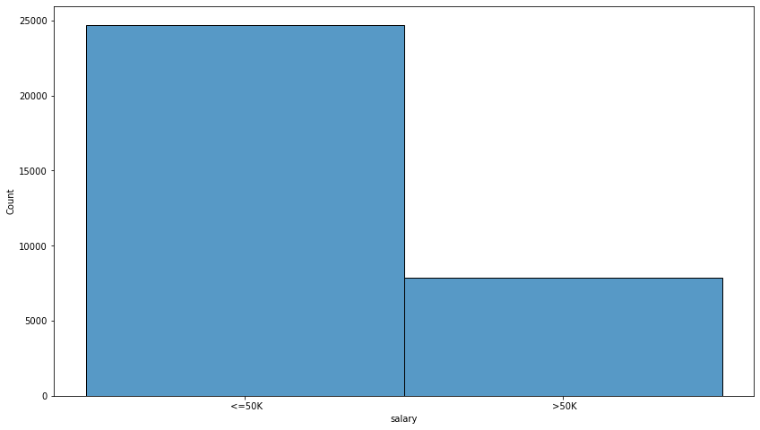

```python
plt.figure(figsize=(14,8))
sns.histplot(data=salaryPredict, x="salary")
```

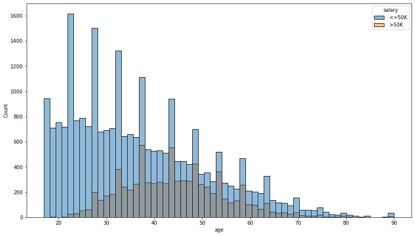

```python
plt.figure(figsize=(14,8))
sns.histplot(data=salaryPredict, x="age",hue='salary')
```

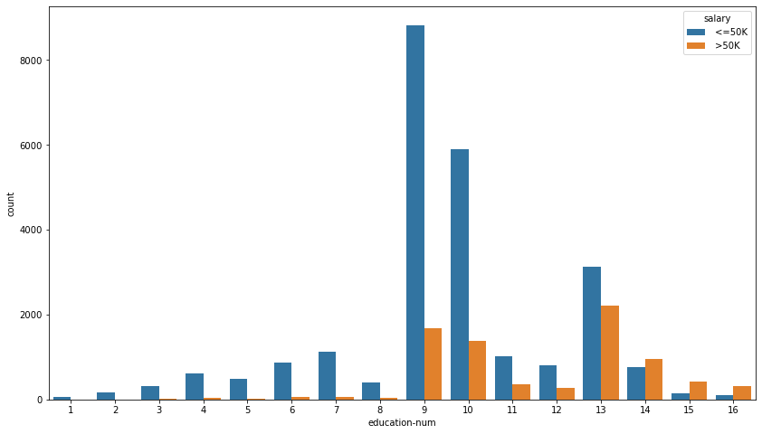

```python
plt.figure(figsize=(14,8))
sns.countplot(data =salaryPredict , x = 'education-num', hue = 'salary')
plt.show()
```

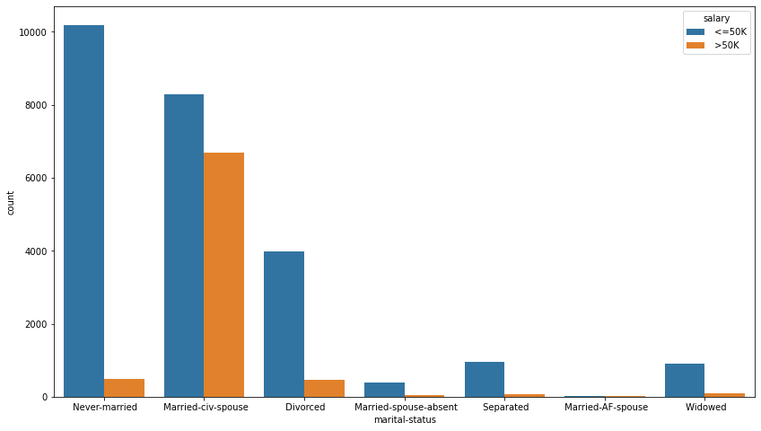

```python
plt.figure(figsize=(14,8))
sns.countplot(data =salaryPredict , x = 'marital-status', hue = 'salary')
plt.show()
```

We can see here that theres seems to be great disparity between the salary of those who are married via civ versus virtually any other status of relationship.

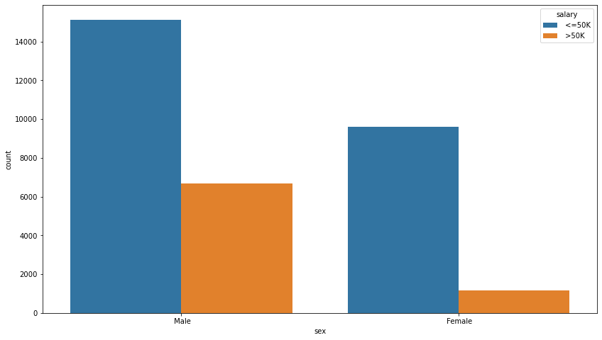

```python
plt.figure(figsize=(14,8))
sns.countplot(data =salaryPredict , x = 'sex', hue = 'salary')
plt.show()
```

Unfortuantley what we see here is that there is a greater chance of someone makign over 50k if they are a male rather than a female.

```python
from sklearn.preprocessing import OrdinalEncoder

enc = OrdinalEncoder()

y = enc.fit_transform(salaryPredict)

colnames = salaryPredict.columns

EncodedSal=pd.DataFrame(y, columns=colnames)
```

```python
EncodedSal.head()
```

|  | age | workclass | fnlwgt | education | education-num | marital-status | occupation | relationship | race | sex | capital-gain | capital-loss | hours-per-week | native-country | salary |
| --- | --- | --- | --- | --- | --- | --- | --- | --- | --- | --- | --- | --- | --- | --- | --- |
| 0 | 22.0 | 7.0 | 2671.0 | 9.0 | 12.0 | 4.0 | 1.0 | 1.0 | 4.0 | 1.0 | 25.0 | 0.0 | 39.0 | 39.0 | 0.0 |
| 1 | 33.0 | 6.0 | 2926.0 | 9.0 | 12.0 | 2.0 | 4.0 | 0.0 | 4.0 | 1.0 | 0.0 | 0.0 | 12.0 | 39.0 | 0.0 |
| 2 | 21.0 | 4.0 | 14086.0 | 11.0 | 8.0 | 0.0 | 6.0 | 1.0 | 4.0 | 1.0 | 0.0 | 0.0 | 39.0 | 39.0 | 0.0 |
| 3 | 36.0 | 4.0 | 15336.0 | 1.0 | 6.0 | 2.0 | 6.0 | 0.0 | 2.0 | 1.0 | 0.0 | 0.0 | 39.0 | 39.0 | 0.0 |
| 4 | 11.0 | 4.0 | 19355.0 | 9.0 | 12.0 | 2.0 | 10.0 | 5.0 | 2.0 | 0.0 | 0.0 | 0.0 | 39.0 | 5.0 | 0.0 |

I am going to remove the continuos variables that have no real value when applyign a classifcation technique predictor to the dataset, that also means id columns.

```python
EncodedSal.pop("fnlwgt")
EncodedSal.pop("capital-gain")
EncodedSal.pop("capital-loss")
EncodedSal.head()
```

|  | age | workclass | education | education-num | marital-status | occupation | relationship | race | sex | hours-per-week | native-country | salary |
| --- | --- | --- | --- | --- | --- | --- | --- | --- | --- | --- | --- | --- |
| 0 | 22.0 | 7.0 | 9.0 | 12.0 | 4.0 | 1.0 | 1.0 | 4.0 | 1.0 | 39.0 | 39.0 | 0.0 |
| 1 | 33.0 | 6.0 | 9.0 | 12.0 | 2.0 | 4.0 | 0.0 | 4.0 | 1.0 | 12.0 | 39.0 | 0.0 |
| 2 | 21.0 | 4.0 | 11.0 | 8.0 | 0.0 | 6.0 | 1.0 | 4.0 | 1.0 | 39.0 | 39.0 | 0.0 |
| 3 | 36.0 | 4.0 | 1.0 | 6.0 | 2.0 | 6.0 | 0.0 | 2.0 | 1.0 | 39.0 | 39.0 | 0.0 |
| 4 | 11.0 | 4.0 | 9.0 | 12.0 | 2.0 | 10.0 | 5.0 | 2.0 | 0.0 | 39.0 | 5.0 | 0.0 |

```python
from sklearn.model_selection import train_test_split

xtr, xtst, ytr, ytst = train_test_split(
    EncodedSal.drop(labels=['salary'], axis=1),
    EncodedSal['salary'],
    test_size=0.3,
    random_state=0)
xtr.shape, xtst.shape
```

```
((22792, 11), (9769, 11))
```

1. For My first method i used what we applied in our first ever homework set, Naives Bayes. I am using the sklearn packages to accomplish the desired result.

```python
from sklearn.preprocessing import OrdinalEncoder # for encoding categorical features from strings to number arrays
from sklearn.naive_bayes import MultinomialNB, CategoricalNB
from sklearn.metrics import confusion_matrix
from sklearn.metrics import accuracy_score

model= CategoricalNB()
model.fit(xtr,ytr)
```

```
CategoricalNB()
```

```python
yhattrain = model.predict(xtr)
pd.crosstab(yhattrain, ytr)
```

| salary row_0 | 0.0 | 1.0 |
| --- | --- | --- |
| 0.0 | 14308 | 1273 |
| 1.0 | 3005 | 4206 |

```python
confusion_matrix(yhattrain, ytr)
accuracy_score(yhattrain, ytr)
```

```
0.8123025623025623
```

1. Here i came back to the method i used in my first project which was regressionw ith feature selection. This method uses a feature seelctor method that chooses which variabels to include in the regression model based off a correlation metric. A graphical representation of that metric can be seen below

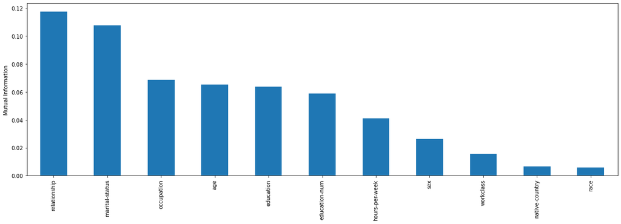

```python
from sklearn.model_selection import train_test_split
from sklearn.feature_selection import mutual_info_classif
from sklearn.feature_selection import SelectKBest

mutinfo = mutual_info_classif(xtr, ytr)
mutinfo
features = pd.Series(mutinfo)
features.index = xtr.columns
features.sort_values(ascending=False).plot.bar(figsize=(20, 6))
plt.ylabel('Mutual Information')
```

It seems as if the variables that have lesser influence on whether someone makes over 50k according to this model is native-country, race, workclass,sex, and hours-per-week. A few of these seem counterintuitive especially from the insights we gathered during the EDA such as the graphical representasiton of whetehr sex has an influence on salary.

```python
sel_ = SelectKBest(mutual_info_classif, k=10).fit(xtr, ytr)

# display features
xtr.columns[select.get_support()]
xtr = sel_.transform(xtr)
xtst = sel_.transform(xtst)
```

```python
from sklearn.linear_model import LogisticRegression
classifier = LogisticRegression(random_state = 0,solver='lbfgs', max_iter=5000)
classifier.fit(xtr, ytr)
ypred = classifier.predict(xtst)
print(ypred)
from sklearn.metrics import accuracy_score
```

```
[0. 0. 0. ... 1. 0. 0.]
```

```python
acc2 = accuracy_score(ytst, ypred)
print(f"Accuracy score: {acc2}")
```

```
Accuracy score: 0.8036646534957519
```